# case1final

Nathaniel Brown, Annie Tang, William Yang

September 13, 2017

### Introduction

In this report, we analyze data from an international validation study to measure the effectiveness of the rat uterotrophic bioassay. The bioassay being studied attempts to measure the estrogenic effect of certain chemicals. The two chemicals used in this study have well known effects, so we would like to verify that the bioassay produces consistent results in rats that have been administered various dosages of the chemicals across two possible protocols. If the uterotrophic bioassay is an effective procedure for measuring the effects of these chemicals, then we expect to see consistent responses to various dosages across all labs and groupings.

To measure the consistency of the responses, we fit iterations of a linear mixed effects model on the provided dataset. The model is conditioned on the labs to account for lab-to-lab variability. Each iteration of the model differs slightly in transformations and conditioning of the predictors/responses until we arrive at a model that we deem most appropriate for the dataset. We then evaluate the final model to determine whether it predicts large variation in responses to the dosages between labs, or if it predicts a consistent measured response to the chemicals.

### Model-Fitting

$$y_{ij} \sim \beta_{0,i} + \beta_{1,i}x_{ij,d_1} + \beta_{2,i}x_{ij,d_2} + \beta_{3,i}x_{ij,p_B} + \beta_{4,i}x_{ij,p_C} + \beta_{5,i}x_{ij,p_D} + \beta_{6,i}x_{ij,log(w)} + \epsilon
\\
\beta_{0:5,i} \sim N(\mu_{0:5,i}, \sigma^2_{0:5,i})
\\
\epsilon \sim N(0, \sigma^2)$$

We start at a reduced form of this model and augment it to its full form after initial analyses.

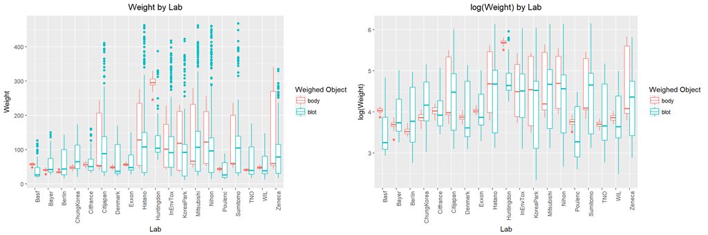

Log Transformations of Weights

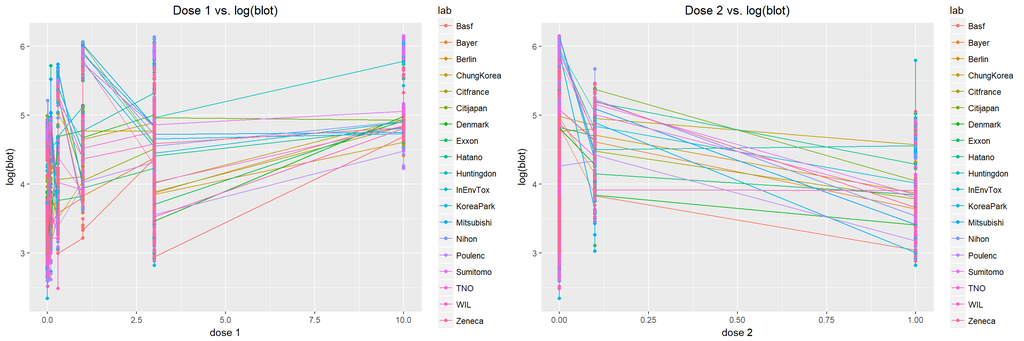

Lab-to-Lab Variability in Intercepts and Slopes

Summary Statistics of Initial Model

|  | Mean Fixed Effects | Variance Fixed Effects |
| --- | --- | --- |
| (Intercept) | 4.9844 | 0.1421 |
| protoB | 0.0397 | 0.0007 |
| protoC | 1.2966 | 0.0193 |
| protoD | 1.2949 | 0.0204 |
| log(body) | -0.0264 | 0.0092 |

|  | Basf | Bayer | Berlin | ChungKorea | Citfrance | Citijapan | Denmark | Exxon | Hatano | Huntingdon | InEnvTox | KoreaPark | Mitsubishi | Nihon | Poulenc | Sumitomo | TNO | WIL | Zeneca |
| --- | --- | --- | --- | --- | --- | --- | --- | --- | --- | --- | --- | --- | --- | --- | --- | --- | --- | --- | --- |
| (Intercept) | -1.6101 | -1.2217 | -1.2500 | -0.8580 | -1.0338 | -1.1414 | -1.0971 | -1.0611 | -1.2059 | -1.5436 | -1.2422 | -1.5166 | -1.1775 | -1.3292 | -1.6289 | -1.1322 | -1.1664 | -1.3140 | -1.3182 |
| dose1 | 0.1838 | 0.1394 | 0.1427 | 0.0979 | 0.1180 | 0.1303 | 0.1252 | 0.1211 | 0.1376 | 0.1762 | 0.1418 | 0.1731 | 0.1344 | 0.1517 | 0.1859 | 0.1292 | 0.1331 | 0.1500 | 0.1505 |
| dose2 | -0.6198 | -0.4303 | -0.2757 | -0.2141 | -0.3777 | -0.5094 | -0.5356 | -0.4524 | -0.5480 | -0.5510 | -0.5843 | -0.6414 | -0.5862 | -0.6054 | -0.5460 | -0.4921 | -0.3356 | -0.4934 | -0.6048 |

| (Intercept) | 1.6181 |
| --- | --- |
| dose1 | 0.0211 |
| dose2 | 0.2691 |

|  | Residual Variance |
| --- | --- |
| residual | 0.1922 |

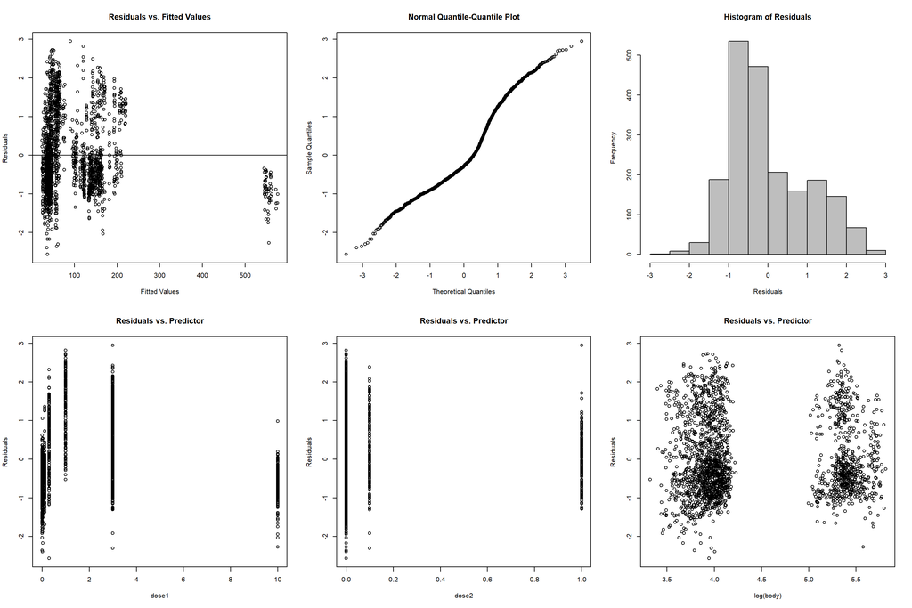

Diagnostic Plots of Initial Model

Among the problems in these plots is the nonlinearity in the Residuals vs. Predictor plot for dose1. To counter this, we transformed dose 1 by the reciprocal of (dose1 + 1/2) (we add a small number to dose because we cannot take the reciprocal of zero). We evaluate this transformed model using summary statistics, diagnostic plots, and out-of-sample predictive accuracy, which we measure using Mean Absolute Error $(\text{MAE} = E[|y - \hat{y}|])$ and Root Mean Squared Error $(\text{RMSE} = \sqrt{E[(y - \hat{y})^2]})$. Root Mean Squared Error penalizes more for extreme errors, while Mean Absolute Error simply averages all of the errors. The results are in the following tables and figures:

Summary Statistics of Transformed Dose 1

|  | Mean Fixed Effects | Variance Fixed Effects |
| --- | --- | --- |
| (Intercept) | 2.6379 | 0.0728 |
| protoB | 0.0457 | 0.0003 |
| protoC | 0.8553 | 0.0094 |
| protoD | 0.8524 | 0.0100 |
| log(body) | 0.2946 | 0.0046 |